# The supplementary for “phyloMDA : An R package for phylogeny-aware microbiome data analysis”

Chao Zhou, Tiantian Liu, Huimin Wang, Hongyu Zhao, and Tao Wang

## 1. Introduction

This is the manual for **phyloMDA**, an R package for phylogeny-aware microbiome data analysis. phyloMDA takes as input a count matrix, a metadata matrix, and a phylogenetic tree. It consists of three modules: multivariate modeling of microbial counts, extraction of relative abundances from counts, and regression with relative abundances as predictors.

### 1.1 Microbiome Data

We illustrate statistical methods for analyzing tree structured microbiome data by applying them to the COMBO dataset from a cross-sectional study on relating dietary habits to gut microbiome [1]. The preprocessed data set consists of a matrix that relates abundances of 62 OTUs to 98 samples, a phylogenetic tree that reflects the evolutionary relationship of these OTUs, and metadata that provide information about the samples such as BMI and measurements of dietary nutrients. We will be working with the [`phyloseq`](http://joey711.github.io/phyloseq/) object.

**Load Packages**

```r
library(phyloseq);
library(ggplot2);
library(phyloMDA);
```

**Load Example Data**

```r
(phyloseq.obj <- combo.phyloseq.obj)
```

```
## phyloseq-class experiment-level object
## otu_table()   OTU Table:         [ 62 taxa and 98 samples ]
## sample_data() Sample Data:       [ 98 samples by 231 sample variables ]
## tax_table()   Taxonomy Table:    [ 62 taxa by 9 taxonomic ranks ]
## phy_tree()    Phylogenetic Tree: [ 62 tips and 61 internal nodes ]
```

**Plot the phylogenetic tree**

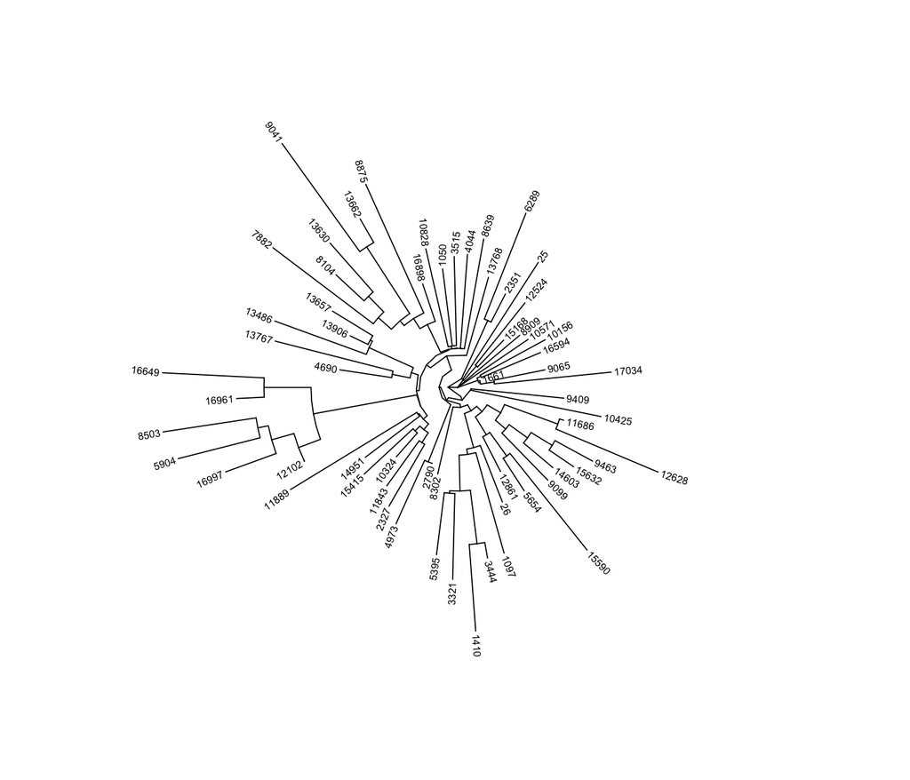

```r
library(ggtree);
ggtree(phyloseq.obj@phy_tree, aes(), layout="fan", size=0.3, ladderize=F) +
  geom_tiplab(size=2, hjust=-0.05, align = F) + theme_tree()
```

**Heatmap of microbial counts**

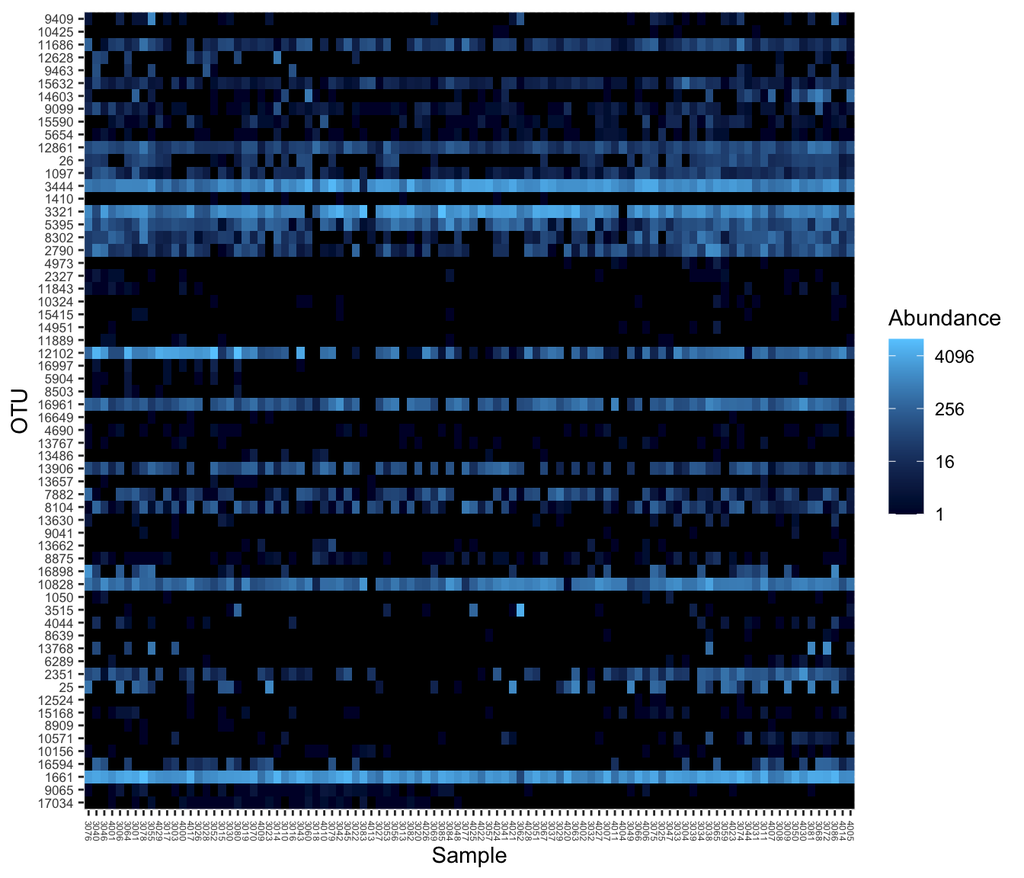

```r
plot_heatmap(phyloseq.obj, taxa.order = taxa_names(phyloseq.obj))
```

**Calculate the proportion of zeros**

```r
otu_tab <- t(phyloseq.obj@otu_table@.Data)
n <- nrow(otu_tab) # sample size
K <- ncol(otu_tab) # number of taxa
zp <- sum(otu_tab==0)/n/K
round(zp, 4) # zero proportion
```

```
## [1] 0.6141
```

**View the metadata**

```r
library(DT);  # an R interface to the JavaScript library DataTables
library(magrittr);  # chaining commands %>%
metadata <- sample_data(phyloseq.obj)
ex_nut <- metadata[, 18:20] %>% round(., 4)
cbind(metadata[, 1:6], ex_nut) %>% datatable() # here only list 3 nutrients
```

|  | pid | visitdate | birthdate | sex1m2f | heightcm | weightkg | calor | prot | afat |
| --- | --- | --- | --- | --- | --- | --- | --- | --- | --- |
| 3001 | 3001 | 4-Dec-09 | 15-Dec-82 | 1 | 180.2 | 70.2 | 0.4673 | -0.2704 | -0.1354 |
| 3003 | 3003 | 7-Dec-09 | 16-Dec-85 | 2 | 165.4 | 59.7 | -0.5339 | -0.9442 | -0.1877 |
| 3004 | 3004 | 10-Dec-09 | 27-Feb-85 | 2 | 152.5 | 46.6 | -1.7446 | -0.616 | -0.3509 |
| 3006 | 3006 | 14-Dec-09 | 24-Jun-76 | 2 | 165.3 | 56.9 | -0.7952 | -0.8081 | -0.7594 |
| 3007 | 3007 | 14-Dec-09 | 13-Nov-80 | 2 | 167.5 | 63.6 | -0.0324 | -0.5435 | -1.9149 |
| 3008 | 3008 | 4-Jan-10 | 8-Sep-63 | 2 | 161.2 | 64.9 | -1.5963 | 1.4268 | -0.5069 |
| 3009 | 3009 | 5-Jan-10 | 24-Feb-79 | 2 | 159.3 | 53.9 | 1.3098 | 1.8501 | -1.5405 |
| 3010 | 3010 | 5-Jan-10 | 27-Oct-67 | 1 | 184 | 95.3 | 0.2837 | 0.0497 | -0.2901 |
| 3011 | 3011 | 11-Jan-10 | 6-Jan-75 | 2 | 159 | 48.9 | 2.554 | -1.6295 | 0.5257 |
| 3013 | 3013 | 15-Jan-10 | 30-May-59 | 2 | 164 | 93.3 | -1.3606 | -0.1174 | 0.6172 |

[output cut: 88 more lines]

**Plot the sum of counts across samples and across taxa**

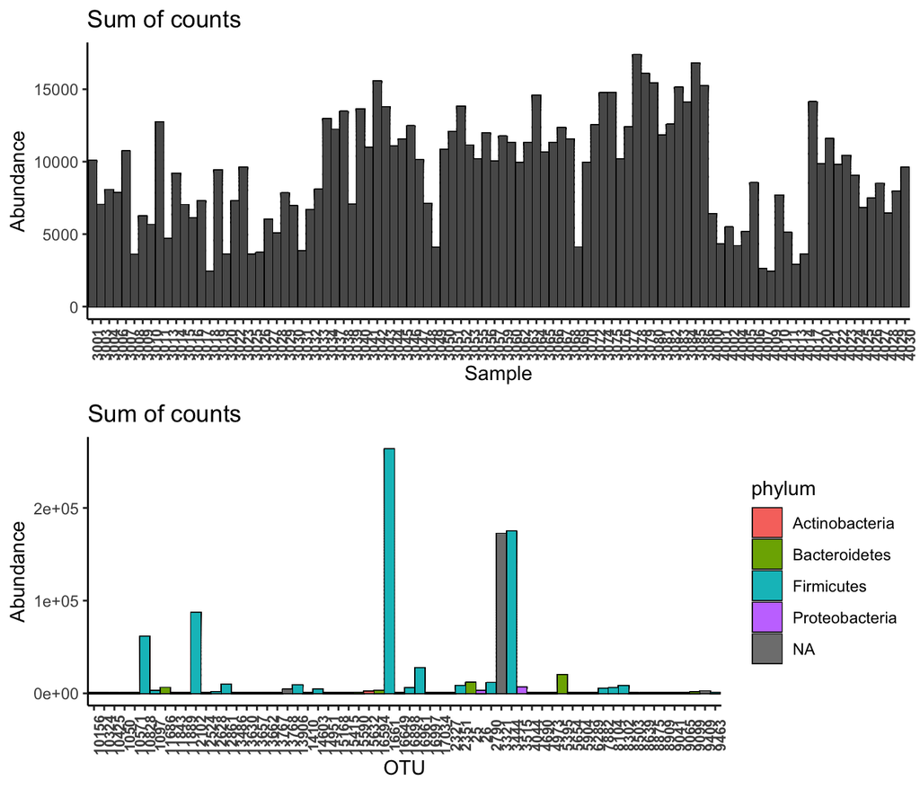

```r
library(ggpubr)   # creating and customizing ggplot2- based publication ready plots
theme_sets <- theme_bw() +  theme(panel.border = element_blank(),
                                  panel.grid.major = element_blank(),
                                  panel.grid.minor = element_blank(),
                                  axis.line = element_line(colour = "black"))

pb1 <- plot_bar(phyloseq.obj) + geom_bar(stat="identity", position="stack") +
   labs(title='Sum of counts') +  theme_sets +
  theme(axis.text.x=element_text(face="bold",size=8,angle=90))

pb2 <- plot_bar(phyloseq.obj, 'OTU',fill="phylum") +
  geom_bar(stat="identity", position="stack") + labs(title='Sum of counts')+ theme_sets +
  theme(axis.text.x=element_text(face="bold",size=8,angle=90))
ggarrange(pb1, pb2, nrow=2, ncol=1)
```

**Visualize the over-dispersion**

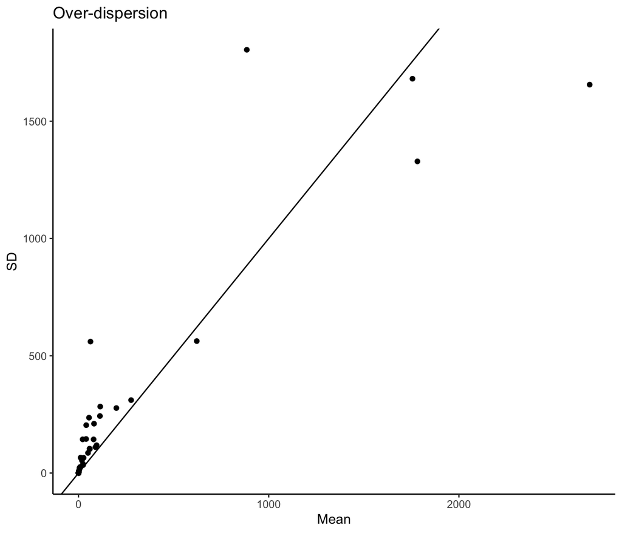

```r
ggplot(data=NULL, aes(x=colMeans(otu_tab), y=apply(otu_tab, 2, sd))) +
  geom_abline(slope = 1, intercept = 0) + geom_point() +
  labs(title='Over-dispersion', x='Mean', y='SD') + theme_sets
```

## 2. Multivariate modeling of microbial counts

One distribution for describing bacterial counts is the multinomial (MN) distribution. We fit this distribution by maximum likelihood. The estimates of probabilities are sample proportions.

**View sample proportions**

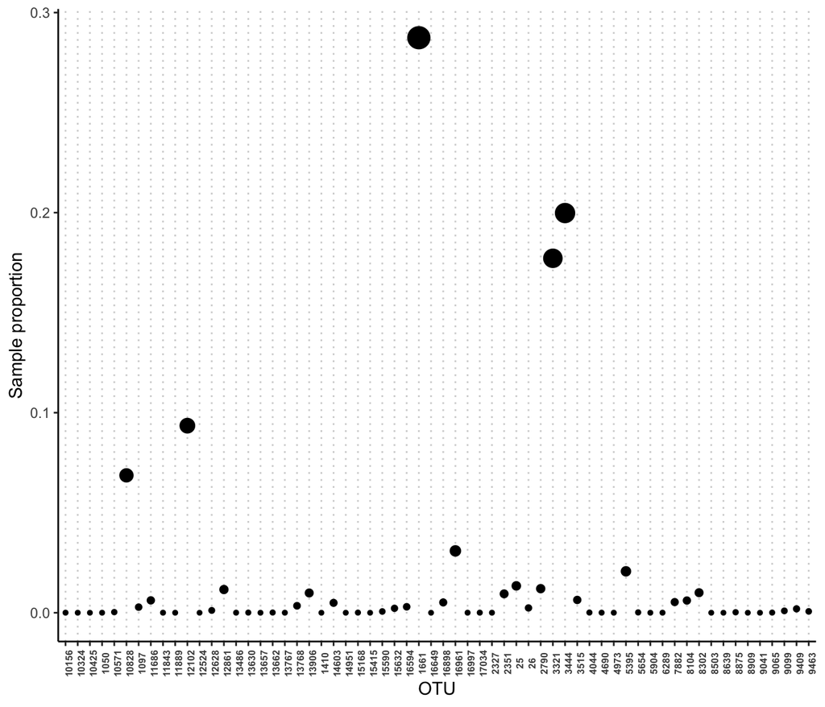

```r
sample_prop  <- colMeans(otu_tab/rowSums(otu_tab))
ggplot(data=NULL, aes(x=names(sample_prop), y=sample_prop, size=sample_prop)) +
  theme_sets +
  theme(axis.text.x=element_text(face="bold",size=6,angle=90), legend.position  = 'none') +
  geom_vline(xintercept = names(sample_prop), linetype="dotted", color='lightgrey') +
  geom_point() +
  labs(x='OTU', y='Sample proportion')
```

In the multinomial-logit regression model, the probabilities of the MN distribution are related to a vector of predictors via the logit linear transformation [2].

**Load Packages**

```r
library(MGLM) # A package for multivariate response generalized linear models
```

**Simple regression with a single predictor**

```r
sodium <- metadata$sodium
reg_mn <- MGLMreg(otu_tab ~ 1 + sodium, dist = 'MN') # MGLMfit fits various multivariate discrete distributions
reg_mn@test # overall test
```

```
##             wald value Pr(>wald)
## (Intercept) 1322196.89         0
## sodium        22716.23         0
```

```r
reg_mn@logL # fitted simple MN regression loglikelihood
```

```
## [1] -388327.3
```

We can also use `MGLM` to fit the MN distribution.

```r
fit_mn <- MGLMfit(data=otu_tab, dist = 'MN')
fit_mn@logL # fitted MN loglikelihood
```

```
## [1] -401364.8
```

### 2.1 Dirichlet-multinomial model

In the presence of over-dispersion, the Dirichlet-multinomial (DM) distribution is a popular alternative to the MN distribution. It is a compound MN distribution with weights from the Dirichlet distribution. DM is MN augmented with one additional parameter (known as the over-dispersion parameter). The function **MGLMfit** can also fit this distribution.

```r
fit_dm <- MGLMfit(data=otu_tab, dist='DM')
fit_dm@logL      # fitted DM loglikelihood
```

```
## [1] -13845.53
```

```r
fit_dm@LRTpvalue # LRT MN vs DM
```

```
## [1] 0
```

To run a regression, the log link is used to relate the parameters to the predictors.

```r
reg_dm <- MGLMreg(otu_tab~1+sodium, dist='DM')
round(reg_dm@test, 4)
```

```
##             wald value Pr(>wald)
## (Intercept) 11851.5553    0.0000
## sodium         81.4292    0.0496
```

```r
reg_dm@logL
```

```
## [1] -13805.07
```

Rather than simple or multiple regression, we can also run penalized regression, which is preferred when the number of predictors (here, nutrient measurements) is comparable to or larger than the sample size. For illustration, we carry out a penaltized DM regression using the first 20 nutrients. The tuning parameters are typically chosen by an information criterion or cross-validation, here we use BIC.

```r
# MGLMsparsereg fits sparse regression in multivariate generalized linear models.
# Other penalty types than “sweep” are allowed
X <-  metadata %>% as.matrix %>% .[,18:37] %>% apply(., 2, as.numeric)
spreg_dm <- MGLMtune(formula = otu_tab~1+X, dist = 'DM', penalty = 'sweep', ngridpt = 20, penidx = c(F, rep(T, 20)))
show(spreg_dm)
```

```
## Call: MGLMtune(formula = otu_tab ~ 1 + X, dist = "DM", penalty = "sweep",
##     ngridpt = 20, penidx = c(F, rep(T, 20)))
##
## Distribution: Dirichlet Multinomial
## Log-likelihood: -13820.67
## BIC: 27953.12
## AIC: 27777.34
## Degrees of freedom: 68
## Lambda: 37.85639
## Number of grid points: 20
```

**Tuning via BIC**

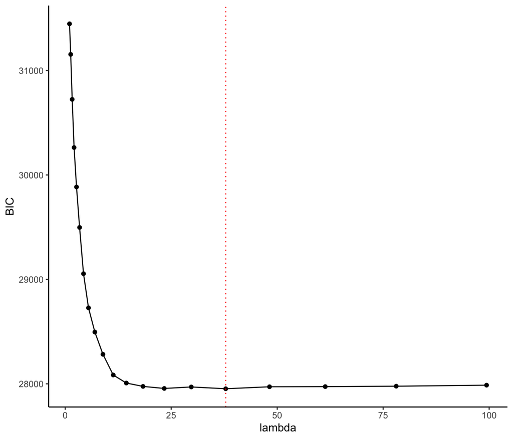

```r
path_res <- spreg_dm@path
ggplot(data=path_res, aes(x=Lambda, y=BIC)) +
  geom_point() + geom_line() + theme_sets + labs(x='lambda') +
  geom_vline(xintercept = spreg_dm@select@lambda, color='red', linetype="dotted")
```

**View estimated coefficients**

```r
spreg_coef <- coef(spreg_dm) %>% t
colnames(spreg_coef) <- c('Intercept', colnames(X))
datatable(round(spreg_coef[, 1:11], 4)) # show the first 10 components
```

| Intercept | calor | prot | afat | vfat | tfat | carbo | aofib | calc | iron | magn |
| --- | --- | --- | --- | --- | --- | --- | --- | --- | --- | --- |
| -2.8949 | 0 | 0 | 0 | 0 | 0 | 0 | 0 | 0 | 0 | 0 |
| -2.6835 | 0 | 0 | 0 | 0 | 0 | 0 | 0 | 0 | 0 | 0 |
| 1.5959 | 0 | 0 | 0 | 0 | 0 | 0 | 0 | 0 | 0 | 0 |
| -2.8028 | 0 | 0 | 0 | 0 | 0 | 0 | 0 | 0 | 0 | 0 |
| -3.4547 | 0 | 0 | 0 | 0 | 0 | 0 | 0 | 0 | 0 | 0 |
| -3.1968 | 0 | 0 | 0 | 0 | 0 | 0 | 0 | 0 | 0 | 0 |
| -4.4997 | 0 | 0 | 0 | 0 | 0 | 0 | 0 | 0 | 0 | 0 |
| -3.0111 | 0 | 0 | 0 | 0 | 0 | 0 | 0 | 0 | 0 | 0 |
| -4.4997 | 0 | 0 | 0 | 0 | 0 | 0 | 0 | 0 | 0 | 0 |
| -2.6663 | 0 | 0 | 0 | 0 | 0 | 0 | 0 | 0 | 0 | 0 |

[output cut: 52 more lines]

### 2.2 (Zero-inflated) Dirichlet-tree multinomial model

To take into account the tree information, Wang, T. and Zhao, H. proposed Dirichlet-tree multinomial (DTM) distribution, defined to be the product of DM distributions that factorize over the phylogenetic tree [3]. Zhou, C, Zhao, H., and Wang T. extended DTM to Zero-inflated DTM (ZIDTM) [4] by the same way. Since the distributions placed on different internal nodes are independent, estimation of the parameters of the DTM model can be carried out separately.

```r
tree <- phy_tree(phyloseq.obj)
fit_dtm <- MGLMdtmFit(otu_tab, tree)
(logL_dtm <- Extract_logL(fit_dtm)) # DTM loglikelihood
```

```
## [1] -13160.69
```

```r
pchisq(2*(logL_dtm - fit_dm@logL), df=61*2-62, lower.tail = F)
```

```
## [1] 7.642585e-247
```

```r
fit_zidtm <- ZIdtmFit(otu_tab, tree)
(logL_zidtm <- Extract_logL(fit_zidtm)) # ZIDTM loglikelihood
```

```
## [1] -13178.28
```

```r
pchisq(2*(logL_zidtm - logL_dtm), df=61*2-62, lower.tail = T)
```

```
## [1] 0
```

```r
reg_dtm <- MGLMdtmReg(otu_tab, sodium, tree)
Extract_logL(reg_dtm) # DTM regression loglikelihood
```

```
## [1] -13132.97
```

```r
reg_zidtm <- ZIdtmReg(otu_tab, X.mean=sodium, tree=tree) # test results for ZIDTM
```

We can also perform penalized DTM regression by running penalized DM in a node-wise manner.

```r
sreg_dtm <- MGLMdtmSparseReg(otu_tab,X, tree, lambda=Inf, penalty="sweep")
Extract_logL(sreg_dtm)
```

```
## [1] -13224.1
```

**Tuning via BIC one each node**

```r
Extract_BIC(sreg_dtm)
```

```
## [1] 26956.14
```

**View estimated coefficients**

```r
spreg_dtmcoef <- lapply(sreg_dtm, function(x) coef(x)) %>% do.call(cbind, .) %>% t
colnames(spreg_dtmcoef) <- c('Intercept', colnames(X))
datatable(round(spreg_dtmcoef[,1:11], 4)) # show the first 10 components
```

| Intercept | calor | prot | afat | vfat | tfat | carbo | aofib | calc | iron | magn |
| --- | --- | --- | --- | --- | --- | --- | --- | --- | --- | --- |
| 1.1548 | 0 | 0 | 0 | 0 | 0 | 0 | 0 | 0 | 0 | 0 |
| 2.052 | 0 | 0 | 0 | 0 | 0 | 0 | 0 | 0 | 0 | 0 |
| 2.3117 | 0 | 0 | 0 | 0 | 0 | 0 | 0 | 0 | 0 | 0 |
| -2.9624 | 0 | 0 | 0 | 0 | 0 | 0 | 0 | 0 | 0 | 0 |
| 2.1515 | 0 | 0 | 0 | 0 | 0 | 0 | 0 | 0 | 0 | 0 |
| -2.2813 | 0 | 0 | 0 | 0 | 0 | 0 | 0 | 0 | 0 | 0 |
| -1.8475 | 0 | 0 | 0 | 0 | 0 | 0 | 0 | 0 | 0 | 0 |
| 4.3427 | 0 | 0 | 0 | 0 | 0 | 0 | 0 | 0 | 0 | 0 |
| 1.9947 | 0 | 0 | 0 | 0 | 0 | 0 | 0 | 0 | 0 | 0 |
| 2.4278 | 0 | 0 | 0 | 0 | 0 | 0 | 0 | 0 | 0 | 0 |

[output cut: 112 more lines]

We also implement tuning version for lambda.

```r
sreg_dtm_tune <- MGLMdtmTune(otu_tab, X, tree, penalty="sweep")
Extract_logL(sreg_dtm_tune) # not run
```

## 3. Extraction of relative abundances from counts

Microbiome data are often normalized prior to downstream analysis. Two widely-used normalization approaches are rarefying and total sum scaling [5]. Liu, T. et al. proposed an empirical Bayes approach for transforming raw counts into relative abundances [6].

### 3.1 Empirical Bayes normalization

Assuming a multinomial distribution for microbial counts and a Dirichlet prior for the proportions, the marginal distribution of each count vector is DM, with the same set of parameters as the prior. We estimate these parameters from OTU counts across samples by maximum likelihood. The empirical Bayes method normalizes the data using the estimated posterior mean.

```r
eBay.comps <- eBay_comps(otu_tab, prior="Dirichlet")
datatable(round(eBay.comps[,1:10],4))
```

|  | 17034 | 9065 | 1661 | 16594 | 10156 | 10571 | 8909 | 15168 | 12524 | 25 |
| --- | --- | --- | --- | --- | --- | --- | --- | --- | --- | --- |
| 3001 | 0.0001 | 0.0002 | 0.3962 | 0 | 0 | 0 | 0 | 0.0006 | 0 | 0.0281 |
| 3003 | 0 | 0.0002 | 0.2493 | 0.0046 | 0 | 0.0014 | 0 | 0 | 0 | 0 |
| 3004 | 0 | 0 | 0.3001 | 0.0075 | 0.0001 | 0 | 0 | 0.0004 | 0 | 0 |
| 3006 | 0 | 0.0005 | 0.4767 | 0 | 0 | 0 | 0 | 0.0004 | 0 | 0.0491 |
| 3007 | 0 | 0 | 0.4135 | 0 | 0 | 0 | 0 | 0.0001 | 0 | 0 |
| 3008 | 0 | 0 | 0.2246 | 0.0179 | 0.0003 | 0.0006 | 0 | 0.0003 | 0 | 0 |
| 3009 | 0 | 0 | 0.2858 | 0 | 0 | 0 | 0 | 0.0002 | 0 | 0.1537 |
| 3010 | 0 | 0.0002 | 0.2304 | 0 | 0 | 0.0007 | 0 | 0 | 0 | 0 |
| 3011 | 0 | 0 | 0.4057 | 0.023 | 0 | 0.0002 | 0 | 0.0004 | 0 | 0.0388 |
| 3013 | 0.0002 | 0 | 0.2784 | 0 | 0 | 0 | 0 | 0 | 0 | 0 |

[output cut: 88 more lines]

### 3.2 Phylogeny-aware normalization

We can further incorporate phylogeny into the normalization process by assuming a Dirichlet-tree prior [6]. The resulting marginal distribution of each count vector is then DTM.

```r
eBay.tree.comps <- eBay_comps(otu_tab, prior="Dirichlet-tree", tree=tree)
datatable(round(eBay.tree.comps[, 1:10], 5))
```

|  | 17034 | 9065 | 1661 | 16594 | 10156 | 10571 | 8909 | 15168 | 12524 | 25 |
| --- | --- | --- | --- | --- | --- | --- | --- | --- | --- | --- |
| 3001 | 0.0001 | 0.00016 | 0.39626 | 1e-05 | 0 | 1e-05 | 0 | 0.00056 | 5e-05 | 0.02816 |
| 3003 | 5e-05 | 8e-05 | 0.24934 | 0.00454 | 1e-05 | 0.00138 | 1e-05 | 0 | 0 | 1e-05 |
| 3004 | 2e-05 | 4e-05 | 0.30008 | 0.00742 | 0.00013 | 1e-05 | 0 | 0.00034 | 3e-05 | 1e-05 |
| 3006 | 0.00015 | 0.00028 | 0.47696 | 1e-05 | 1e-05 | 1e-05 | 0 | 0.00036 | 3e-05 | 0.04921 |
| 3007 | 2e-05 | 3e-05 | 0.41353 | 1e-05 | 0 | 1e-05 | 0 | 9e-05 | 1e-05 | 1e-05 |
| 3008 | 3e-05 | 5e-05 | 0.22475 | 0.01767 | 0.00029 | 0.00053 | 1e-05 | 0.00026 | 2e-05 | 3e-05 |
| 3009 | 3e-05 | 4e-05 | 0.28578 | 1e-05 | 1e-05 | 1e-05 | 0 | 0.00016 | 1e-05 | 0.15395 |
| 3010 | 5e-05 | 9e-05 | 0.2304 | 1e-05 | 1e-05 | 0.00068 | 1e-05 | 1e-05 | 0 | 1e-05 |
| 3011 | 2e-05 | 3e-05 | 0.40579 | 0.02299 | 0 | 0.00024 | 0 | 0.00037 | 3e-05 | 0.03887 |
| 3013 | 7e-05 | 0.0001 | 0.27843 | 2e-05 | 1e-05 | 2e-05 | 0 | 1e-05 | 0 | 1e-05 |

[output cut: 88 more lines]

### 3.3 Statistical analysis of compositional data

Microbiome data are compositional and should be treated as compositions. However, since compositions are constrained by the simplex, the analysis of compositional data using traditional tools can be misleading [7]. One way to address this issue is to use ratio transformations and then take the logarithm of these ratios, known as log-ratios. Often, the additive log-ratio and centered log-ratio transformations are used.

```r
comps_alr <- alr_trans(eBay.comps)
comps_clr <- clr_trans(eBay.comps)
```

### 3.4 Diversity estimation

When the compositions are extracted from microbial count data, downstream analyses such as diversity estimation, and compositionally aware data analysis are easily achievable. Here, we present two types of diversity estimation: alpha diversity and beta diversity.

- alpha diversity

```r
library(vegan)
meta_sam <- metadata %>% .[.$bmicat1norm2ow3ob!=2, ]
eBay.comps_sub <- eBay.comps[as.character(meta_sam$pid),]
Shannon.Wiener <- diversity(eBay.comps_sub, index = "shannon")
Simpson <- diversity(eBay.comps_sub, index = "simpson") #Simpson
Inverse.Simpson <- diversity(eBay.comps_sub, index = "inv") #Inverse Simpson
group <- c()
group[which(meta_sam$bmicat1norm2ow3ob==1)] <- "normal"
group[which(meta_sam$bmicat1norm2ow3ob==3)] <- "obese"

library(ggpubr) ###
div.sha <- data.frame(shannon = Shannon.Wiener,group= group)
pic1 <- ggboxplot(div.sha,
                  x="group",
                  y="shannon",
                  color="group",
                  palette = "jama",legend = "right",
                  add = "jitter",xlab="Group",ylab="alpha diversity",title="Shannon")+
  theme(plot.title = element_text(hjust = 0.5))

simp.sha <- data.frame(simpson = Simpson,group= group)
pic2 <- ggboxplot(simp.sha,
                  x="group",
                  y="simpson",
                  color="group",
                  palette = "jama", legend = "right",
                  add = "jitter",xlab="Group",ylab="alpha diversity",title="Simpson")+
  theme(plot.title = element_text(hjust = 0.5))

isimp.sha <- data.frame(isimpson = Inverse.Simpson,group= group)
pic3 <- ggboxplot(isimp.sha,
                  x="group",
                  y="isimpson",
                  color="group",
                  palette = "jama",legend = "right",
                  add = "jitter",xlab="Group",ylab="alpha diversity",title="Inverse.Simpson")+
  theme(plot.title = element_text(hjust = 0.5))+
  theme(axis.text = element_text(size = 13), axis.title = element_text(size = 15), legend.text = element_text(size = 11))
g123 <- ggarrange(pic1,pic2,pic3,nrow=1,common.legend = TRUE)
```

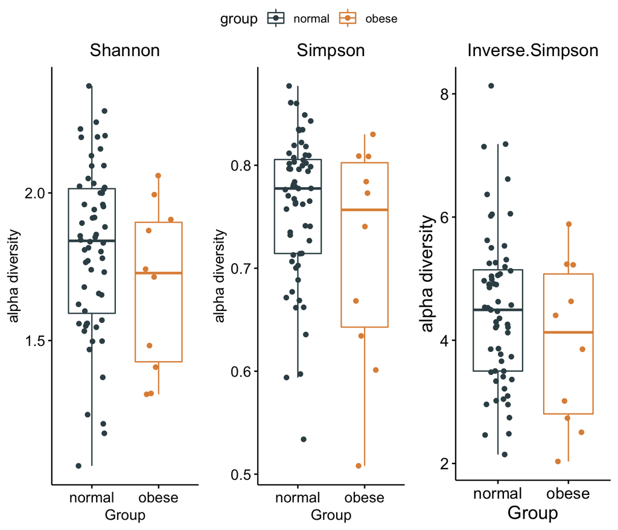

```r
g123
```

- beta diversity

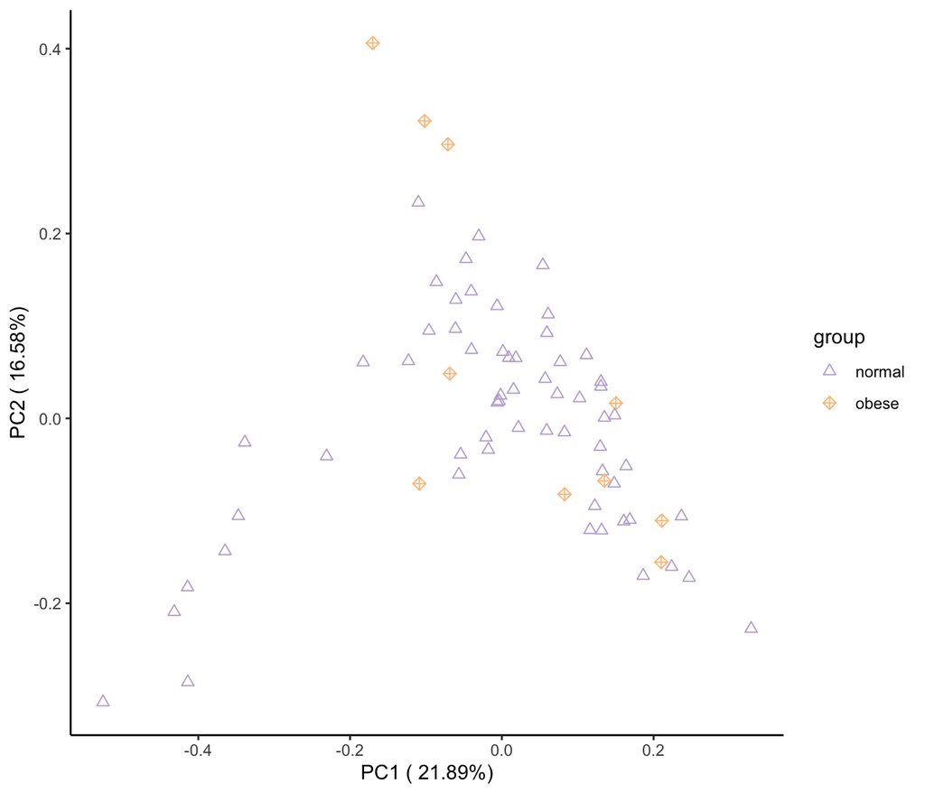

```r
df_pca <- prcomp(eBay.comps_sub)
df_pcs <-data.frame(df_pca$x, group =  group)

percentage<-round(df_pca$sdev / sum(df_pca$sdev) * 100,2)
percentage<-paste(colnames(df_pcs),"(", paste(as.character(percentage), "%", ")", sep=""))
df_pcs$group <- as.factor(group)
library(RColorBrewer)
col <- brewer.pal(8,"Accent")[c(2,3)]
ggplot(df_pcs,aes(x=PC1,y=PC2,color=group,shape=group)) + geom_point(size=2)+
  xlab(percentage[1]) + ylab(percentage[2]) +
  scale_fill_manual(values=col)+
  scale_colour_manual(values=col)+
  scale_shape_manual(values = c(2, 9))+
  theme_classic()
```

### 3.5 Differential abundance analysis: An illustration

To illustrate the usefulness of the empirical Bayes method, we apply it to the COMBO dataset for differential abundance testing. We categorize the covariate BMI as normal weight, overweight, and obese, and focus on the normal weight and obese individuals. There are 70 individuals and 62 OTUs.

```r
meta_sam <- metadata %>% .[.$bmicat1norm2ow3ob!=2, ]
comps_clr_sub <- comps_clr[as.character(meta_sam$pid), ]

comps_test <- apply(comps_clr_sub, 2, function(x) { t.test(x[meta_sam$bmicat1norm2ow3ob==1],
                                                           x[meta_sam$bmicat1norm2ow3ob==3])$p.value })
dif.otus <- names(which(p.adjust(comps_test, 'fdr')<0.05))
tax.dif.otus <- tax_table(phyloseq.obj)[dif.otus, ]
# colnames(tax.dif.otus) <- "taxanomy"
datatable(tax.dif.otus)
```

|  | root | kingdom | phylum | class | order | family | genus | species | none |
| --- | --- | --- | --- | --- | --- | --- | --- | --- | --- |
| 25 | Root | Bacteria | Bacteroidetes | Bacteroidetes | Bacteroidales | Bacteroidaceae | Bacteroides |  |  |
| 16898 | Root | Bacteria | Firmicutes | Clostridia | Clostridiales | Ruminococcaceae |  |  |  |
| 13906 | Root | Bacteria | Firmicutes | Clostridia | Clostridiales | Lachnospiraceae |  |  |  |
| 9409 | Root | Bacteria |  |  |  |  |  |  |  |

We also compared eBay to other differential abundance testing methods, such as MetagenomeSeq, DESeq2, ANCOM, rarefying, total sum scaling (tss).

**Load Packages**

```r
library(metagenomeSeq);
library(DESeq2);
source('/Users/tiantian/Downloads/ancom_functions.r')
library(UpSetR);
```

**metagenomeSeq**

```r
otu_tab_sub <- otu_tab[rownames(meta_sam), ]
phenotypeData <- AnnotatedDataFrame(meta_sam)
obj_meta <- newMRexperiment(t(otu_tab_sub),phenoData=phenotypeData) %>% cumNorm(., p = 0.5)
mod_meta <- model.matrix(~meta_sam$bmicat1norm2ow3ob,data = environment(obj_meta))
res_meta <- fitFeatureModel(obj = obj_meta, mod = mod_meta)%>% MRcoefs(.,number=ncol(otu_tab_sub))
res_meta.final <- rownames(res_meta)[which(res_meta$adjPvalues<0.05)]
#####MetagenomeSeq  failed to detect any OTU###
```

**DESeq2**

```r
group <- meta_sam$bmicat1norm2ow3ob
deseq_data <- DESeqDataSetFromMatrix(t(otu_tab_sub+1), DataFrame(group), ~ group)
res_deseq <- estimateSizeFactors(deseq_data) %>%estimateDispersions %>%nbinomWaldTest %>% results(.)
res_deseq.final <- rownames(res_deseq)[which(res_deseq$padj<0.05)]
```

**ANCOM**

```r
res_ancom <- ANCOM(OTUdat=data.frame(otu_tab_sub,Group=group),
                 sig=0.05, multcorr=3, tau=0.02, theta=0.1, repeated=FALSE)$detected
res_ancom <- gsub('X', '', res_ancom)
```

**rarefying**

```r
otu <- otu_table(as.matrix(t(otu_tab_sub)), taxa_are_rows=TRUE)
sample_data <- sample_data(meta_sam)
phyloseq.obj.sub <- phyloseq(otu, sample_data)
phyloseq.obj.rare <- rarefy_even_depth(phyloseq.obj.sub, sample.size = min(sample_sums(phyloseq.obj.sub))*0.9 ,rngseed = 2018)
res_rare <- apply(otu_table(phyloseq.obj.rare), 1, function(x) {
  t.test(x[meta_sam$bmicat1norm2ow3ob==1], x[meta_sam$bmicat1norm2ow3ob==3])$p.value
})
res_rare.final <- names(which(p.adjust(res_rare, 'BH') < 0.05))
#####rerafying  failed to detect any OTU###
```

**tss**

```r
otu_tab_rep <- otu_tab_sub
otu_tab_rep[otu_tab_rep==0] <- 0.5
otu_tab_tss <- otu_tab_rep/rowSums(otu_tab_rep)
tss_clr <- apply(otu_tab_tss, 1, function(x){log2(x) - mean(log2(x))})

res_tss <- apply(tss_clr, 1, function(x) { t.test(x[meta_sam$bmicat1norm2ow3ob==1],
                                                  x[meta_sam$bmicat1norm2ow3ob==3])$p.value })
res_tss.final <- names(which(p.adjust(res_tss, 'BH') < 0.05))
```

**none**

```r
res_raw <- apply(otu_tab_sub, 2, function(x) {t.test(x[meta_sam$bmicat1norm2ow3ob==1], x[meta_sam$bmicat1norm2ow3ob==3])$p.value })
res_raw.final <- names(which(p.adjust(res_raw, 'BH') < 0.05))
```

The results are shown as follows:

```r
dataForUpSetPlot <- list("none-t"=res_raw.final,
                         "tss-t"=res_tss.final,
                         "rarefying-t"=res_rare.final,
                        "metagenomeSeq"=res_meta.final,
                        "eBay-t"=dif.otus,
                        "eBay-tree-t"=dif.otus,
                        "DESeq2"=res_deseq.final,
                        "ANCOM"=res_ancom)

setsBarColors <-c("dodgerblue", "goldenrod1", "darkorange1", "seagreen3", "orchid3",  'brown2', 'pink',"dodgerblue1")

res <- upset(fromList(dataForUpSetPlot),
      nsets=length(dataForUpSetPlot),
      keep.order = TRUE,
      point.size = 1,
      line.size = 0.5,
      number.angles = 0,
      shade.alpha=1,
      matrix.dot.alpha=1,
      text.scale = c(1.5, 1.2, 1.2, 1, 1.5, 1),
      matrix.color="black",
      main.bar.color = 'black',
      mainbar.y.label = 'Intersection Size',
      sets.bar.color=setsBarColors)
```

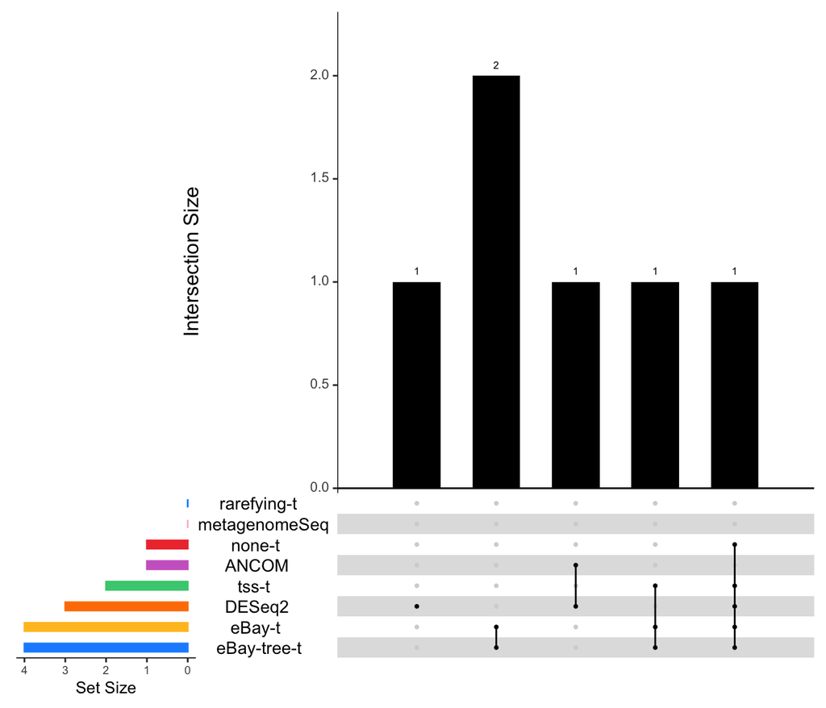

```r
res
```

## 4. Regression with relative abundances as predictors

In some machine learning applications, microbiome relative abundance data are used as predictors or inputs that have some influence on one or more outputs [8]. This section is concerned with regression problems where the predictors are compositional data and the response is univariate.

### 4.1 Constrained lasso and log-ratio lasso

**Load Packages**

```r
library(logratiolasso) # An R implementation of the constrained lasso and two-stage logratio lasso.
source("/Users/tiantian/Downloads/plot_onTree.R")
```

```r
y <- metadata$bmi
x <- eBay.comps %>% log2 # log of estimated microbiome compositions

centered_y <- y - mean(y)
centered_x <- scale(x, center=T, scale=F)

# constrained lasso
constrain_lasso <- glmnet.constr(centered_x, centered_y, family = 'gaussian')
set.seed(10)
cv_constrain_lasso <- cv.glmnet.constr(constrain_lasso, centered_x, centered_y)
# str(cv_constrain_lasso),
# two-stage log-ratio lasso
set.seed(10)
cv_ts_lasso <- cv_two_stage(centered_x, centered_y, k_max = 7) # str(cv_ts_lasso)
```

```
## [1] "Starting CV fold 1"
## [1] "Starting CV fold 2"
## [1] "Starting CV fold 3"
## [1] "Starting CV fold 4"
## [1] "Starting CV fold 5"
## [1] "Starting CV fold 6"
## [1] "Starting CV fold 7"
## [1] "Starting CV fold 8"
## [1] "Starting CV fold 9"
## [1] "Starting CV fold 10"
```

**Plots of the CV estimates of error**

```r
gl1 <- ggplot(data=NULL, aes(x=cv_constrain_lasso$lambda, cv_constrain_lasso$cvm)) +
  geom_point() + geom_line() + labs(title='constrained lasso', x='lambda', y='CV error')+ theme_sets +
  geom_vline(xintercept = cv_constrain_lasso$lambda[which.min(cv_constrain_lasso$cvm)],
             color='red', linetype="dotted")
gl2 <- ggplot(data=NULL, aes(x=cv_ts_lasso$lambda, y=cv_ts_lasso$mse[cv_ts_lasso$k_min,])) +
  geom_point() + geom_line() + labs(title='two-stage log-ratio lasso', x='lambda', y='CV error') +
  theme_sets +
  geom_vline(xintercept = cv_ts_lasso$lambda[cv_ts_lasso$lambda_min], color='red',
             linetype="dotted")

gl12 <- ggarrange(gl1, gl2, nrow=1)
```

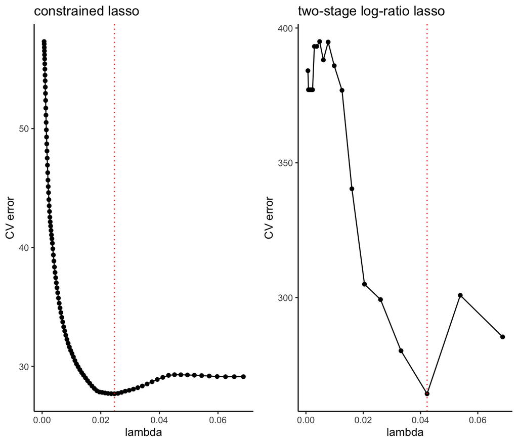

```r
gl12
```

**View estimated coefficients**

```r
beta12 <- data.frame(b1=cv_constrain_lasso$beta, b2=cv_ts_lasso$beta_min)
colnames(beta12) <- c('constrained lasso',  'two-stage log-ratio lasso')
datatable(round(beta12[rowSums(beta12)!=0, ], 4))
```

|  | constrained lasso | two-stage log-ratio lasso |
| --- | --- | --- |
| 25 | -0.0682 | -0.1044 |
| 2351 | -0.1354 | -0.2785 |
| 16898 | -0.0955 | -0.242 |
| 8875 | 0.0001 | 0 |
| 13906 | 0.1882 | 0.3664 |
| 12628 | 0.1564 | 0.2585 |
| 11686 | -0.0481 | 0 |

### 4.2 Phylogeny-aware subcomposition selection

Since a composition carries only relative information, subcompositions, which preserve ratio relationships, are fundamental objects of investigation in compositional data analysis. In the regression setting, Wang, T. and Zhao, H. proposed a multiscale method, Tree-guided Automatic Subcomposition Selection Operator (**TASSO**), for selecting subcompositions at subtree levels [12]. The criterion for TASSO contains two penalty terms corresponding to leaf nodes and internal nodes, respectively. The TASSO solution is obtained by solving a generalized lasso problem [13].

**Load Packages**

```r
library(genlasso)
```

```r
# constrained lasso (genlasso)
fit1_tasso <- TASSO(y,eBay.comps,tree=NULL)

# TASSO
fit2_tasso <- TASSO(y, eBay.comps,tree)
#str(fit2_tasso)
```

**Tuning via BIC**

```r
# BIC for constrained lasso and TASSO
fit1_tasso_IC <- ICgenlasso(fit1_tasso)
fit2_tasso_IC <- ICgenlasso(fit2_tasso)

gf1 <- ggplot(data=fit1_tasso_IC, aes(x=lambda, y=BIC)) + geom_line() +
  geom_point()  + theme_sets + labs(title='constrained lasso (genlasso)') +
  geom_vline(xintercept = fit1_tasso_IC$lambda[which.min(fit1_tasso_IC$BIC)], color='red', linetype='dotted')
gf2 <- ggplot(data=fit2_tasso_IC, aes(x=lambda, y=BIC)) +
  geom_point() + geom_line() + theme_sets + labs(title='TASSO') +
  geom_vline(xintercept = fit2_tasso_IC$lambda[which.min(fit2_tasso_IC$BIC)], color='red', linetype='dotted')
gf12 <- ggarrange(gf1, gf2, nrow=1)
```

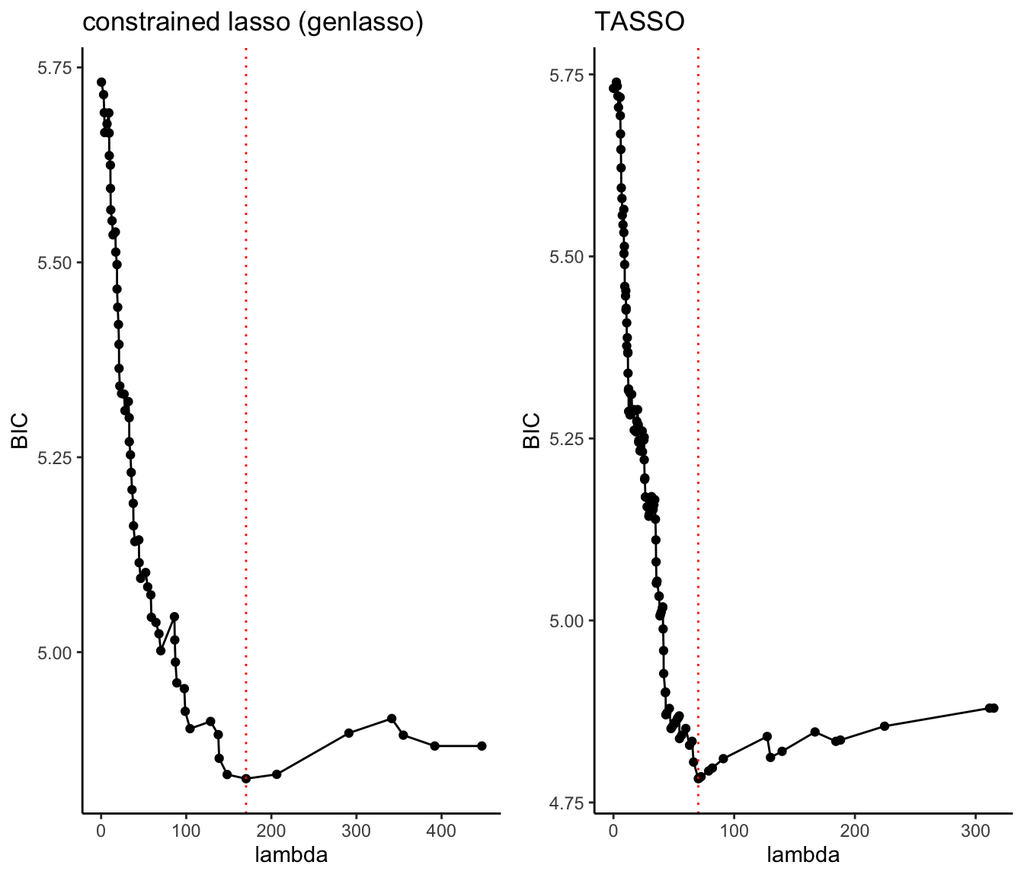

```r
gf12
```

**View estimated coefficients**

```r
fit1_beta <- fit1_tasso$beta[, which.min(fit1_tasso_IC$BIC)]
fit1_beta <- round(fit1_beta - mean(fit1_beta) , 8)
fit2_beta <- fit2_tasso$beta[, which.min(fit2_tasso_IC$BIC)]
fit2_beta <- round(fit2_beta - mean(fit2_beta) , 8)


tasso_beta12 <- data.frame(b1=beta12[,1], b2=fit1_beta, b3=beta12[,2], b4=fit2_beta)
colnames(tasso_beta12) <- c('constrained lasso', 'constrained lasso (genlasso)', 'two-stage log-ratio lasso', 'TASSO')
rownames(tasso_beta12) <- taxa_names(phyloseq.obj)
tasso_beta12_nonzero <- tasso_beta12[rowSums(tasso_beta12)!=0, ]
datatable(round(tasso_beta12_nonzero, 4))
```

|  | constrained lasso | constrained lasso (genlasso) | two-stage log-ratio lasso | TASSO |
| --- | --- | --- | --- | --- |
| 25 | -0.0682 | -0.0998 | -0.1044 | 0 |
| 2351 | -0.1354 | -0.1954 | -0.2785 | -0.0876 |
| 6289 | 0 | 0 | 0 | 0.0876 |
| 16898 | -0.0955 | -0.1353 | -0.242 | -0.2231 |
| 8875 | 0.0001 | 0 | 0 | 0.2231 |
| 13657 | 0 | 0 | 0 | -0.2084 |
| 13906 | 0.1882 | 0.2703 | 0.3664 | 0.2084 |
| 12628 | 0.1564 | 0.2251 | 0.2585 | 0.3598 |
| 11686 | -0.0481 | -0.0648 | 0 | -0.3598 |

**Visualize the TASSO results on the tree**

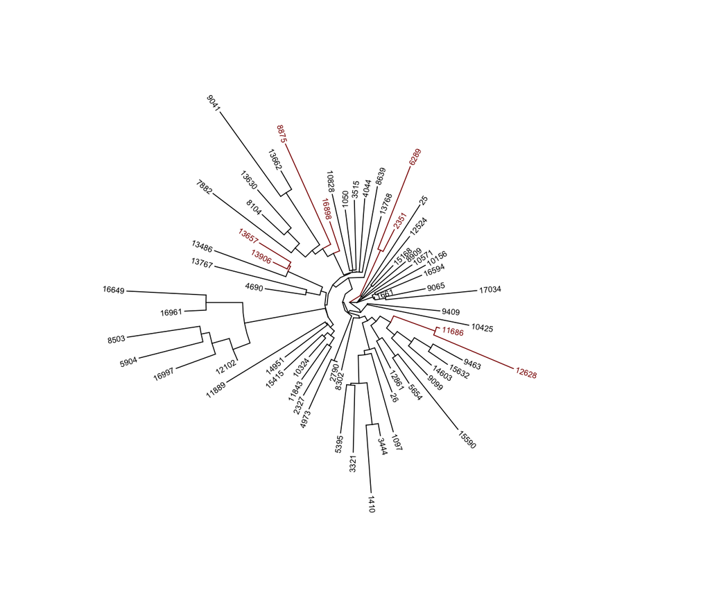

```r
plot_onTree(fit2_tasso, tree=tree, model = 'TASSO')
```